# prep_descriptives

Niamh MacSweeney

2023-02-09

## Introduction

This script is for a project with N. MacSweeney, P.Thomson, and D. Rakesh on threat exposure, pubertal maturation, and depression risk in female adolescents.

Preregistration available here: https://osf.io/txsvh (uploaded to OSF on 23.05.23)

## Set up

###Requirements Data: ABCD data release 4.0 (see data dictionary: https://nda.nih.gov/data_dictionary.html?source=ABCD%2BRelease%2B4.0&submission=ALL)

Variable names - Trauma: [ABCD Diagnostic Interview for DSM-5 (KSADS) Traumatic Events]: abcd_ptsd01 (parent report); - Pubertal development [Pubertal development scale]: abcd_ypdms01 (youth report); abcd_ppdms01 (parent report) - Mental health [ABCD Youth Summary Scores BPM and POA]: abcd_yssbpm01

[output not shown]

Main variables: - PTSD - PDS - BPM

Covariates - Site - Family

Sensitivity analyses - Family income (to needs ratio) - Parental education - Race - BMI

Inspect sample sizes for each variable

Timepoints:

- Trauma at baseline: N = 5680 (females); N = 6196 (males)
- Puberty available at baseline (N = full sample), year 1, year 2, year 3 (same as mental health at year 3)
- Mental Health at 3 year follow up: N = 2955 (females); N = 3296 (males)

```
## # A tibble: 8 × 3
## # Groups:   eventname, sex [8]
##   eventname                sex       n
##   <chr>                    <chr> <int>
## 1 1_year_follow_up_y_arm_1 F      5353
## 2 1_year_follow_up_y_arm_1 M      5872
## 3 2_year_follow_up_y_arm_1 F      4962
## 4 2_year_follow_up_y_arm_1 M      5452
## 5 3_year_follow_up_y_arm_1 F      2955
## 6 3_year_follow_up_y_arm_1 M      3296
## 7 baseline_year_1_arm_1    F      5680
## 8 baseline_year_1_arm_1    M      6196
```

```
## # A tibble: 8 × 3
## # Groups:   eventname, sex [8]
##   eventname                sex       n
##   <chr>                    <chr> <int>
## 1 1_year_follow_up_y_arm_1 F      5353
## 2 1_year_follow_up_y_arm_1 M      5872
## 3 2_year_follow_up_y_arm_1 F      4962
## 4 2_year_follow_up_y_arm_1 M      5452
## 5 3_year_follow_up_y_arm_1 F      2955
## 6 3_year_follow_up_y_arm_1 M      3296
## 7 baseline_year_1_arm_1    F      5680
## 8 baseline_year_1_arm_1    M      6196
```

```
## # A tibble: 8 × 3
## # Groups:   eventname, sex [8]
##   eventname                sex       n
##   <chr>                    <chr> <int>
## 1 1_year_follow_up_y_arm_1 F      5353
## 2 1_year_follow_up_y_arm_1 M      5872
## 3 2_year_follow_up_y_arm_1 F      4962
## 4 2_year_follow_up_y_arm_1 M      5452
## 5 3_year_follow_up_y_arm_1 F      2955
## 6 3_year_follow_up_y_arm_1 M      3296
## 7 baseline_year_1_arm_1    F      5680
## 8 baseline_year_1_arm_1    M      6196
```

```
## # A tibble: 12 × 3
## # Groups:   eventname, sex [12]
##    eventname                sex       n
##    <chr>                    <chr> <int>
##  1 18_month_follow_up_arm_1 F      5281
##  2 18_month_follow_up_arm_1 M      5808
##  3 1_year_follow_up_y_arm_1 F      5353
##  4 1_year_follow_up_y_arm_1 M      5872
##  5 2_year_follow_up_y_arm_1 F      4962
##  6 2_year_follow_up_y_arm_1 M      5452
##  7 30_month_follow_up_arm_1 F      4081
##  8 30_month_follow_up_arm_1 M      4470
##  9 3_year_follow_up_y_arm_1 F      2955
## 10 3_year_follow_up_y_arm_1 M      3296
## 11 6_month_follow_up_arm_1  F      5426
## 12 6_month_follow_up_arm_1  M      5970
```

## Data Cleaning

### PDS

We will use parent PDS scores due to high amount of missing data at earlier timepoints for youth self report.

The Pubertal Development Scale (PDS; Petersen et al., 1988) will be used to examine the perceived development of secondary sex characteristics such as growth spurts, body hair growth, skin changes, breast development and menarche in girls, and voice changes and growth of facial hair in boys. The PDS includes five-items, and each characteristic is rated on a 4-point scale (1 = no development; 2 = development has barely begun; 3 = development is definitely underway; and 4 = development is complete; except menstruation, which is coded 1 = has not begun, 4 = has begun). Thus, higher scores reflect more advanced pubertal maturation. We will use average PDS scores from T1, T2, and T3 as our measure of perceived physical pubertal development at each timepoint. In line with existing research that used ABCD PDS data (Herting et al., 2021), items were considered missing if a response was left blank or answered “I don’t know” or “refused to answer”. Further, if participants had a missing value for any of the five items used to calculate the average PDS score, their average PDS score was coded as “missing”.

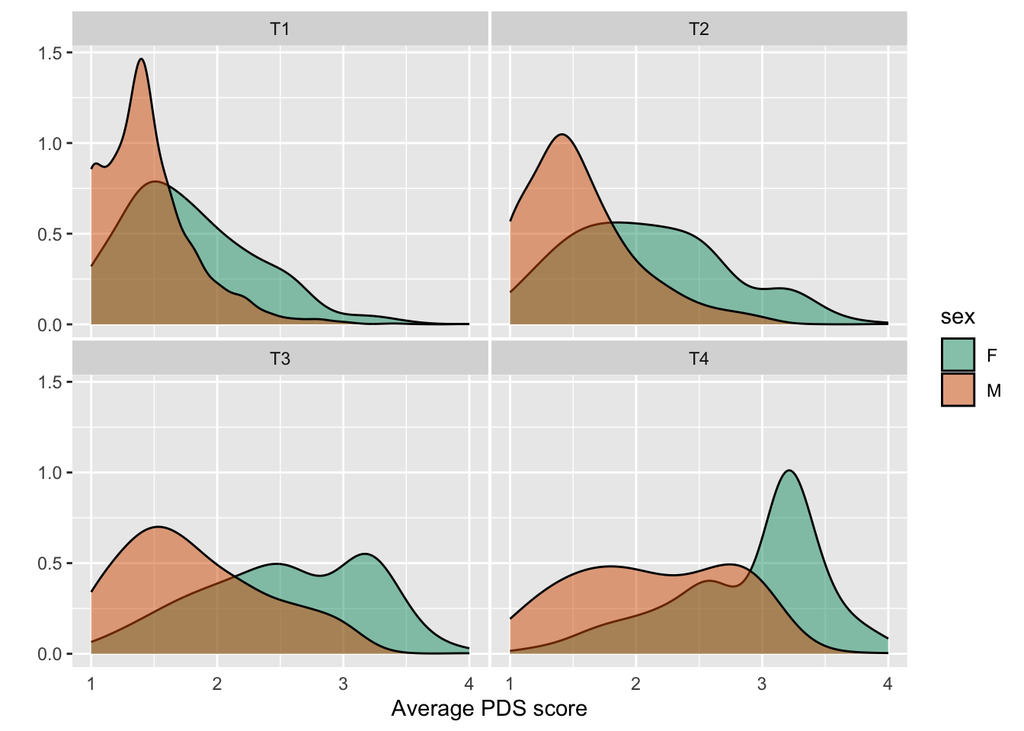

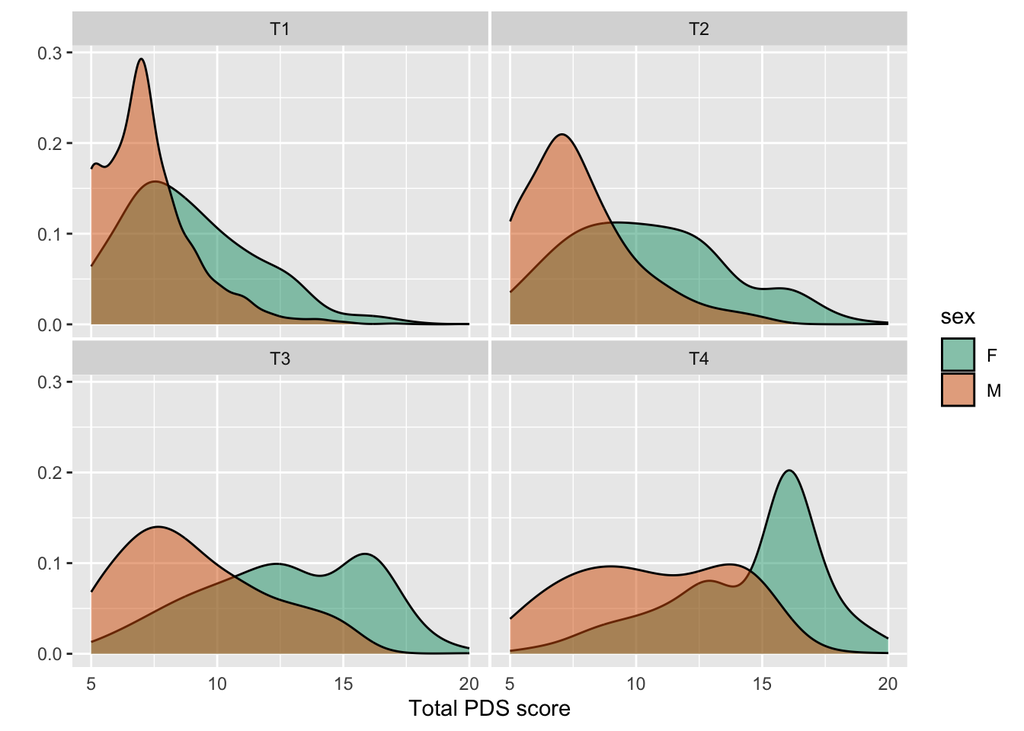

Let’s look at a raincloud plot to see changes in PDS average scores over time Can see clear differences between sexes.

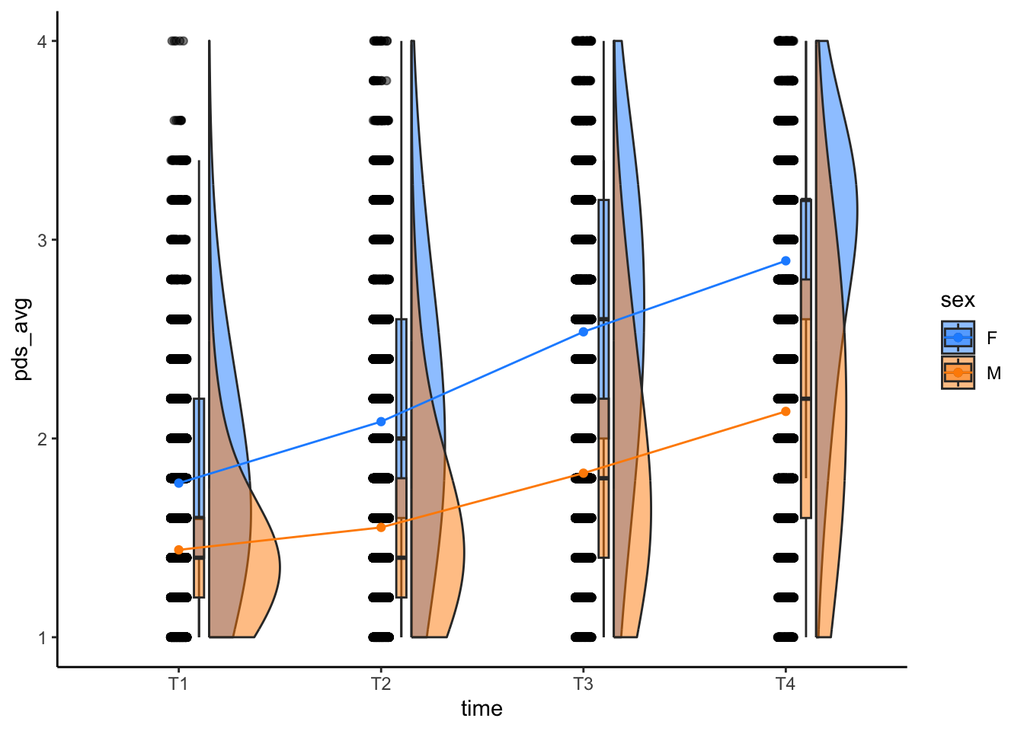

Get female sample only

Make table for parent PDS to check for missing values (females only)

| **Characteristic** | **T1**, N = 5,680<sup>1</sup> | **T2**, N = 5,353<sup>1</sup> | **T3**, N = 4,962<sup>1</sup> | **T4**, N = 2,955<sup>1</sup> | **p-value**<sup>2</sup> |
| --- | --- | --- | --- | --- | --- |
| age | 118.81 (7.48) | 130.90 (7.72) | 143.91 (7.99) | 154.56 (7.63) | <0.001 |
| Height change |  |  |  |  | <0.001 |
| 1 | 795 / 5,454 | 509 / 5,220 | 265 / 4,847 | 85 / 2,865 |  |
| 2 | 900 / 5,454 | 921 / 5,220 | 640 / 4,847 | 275 / 2,865 |  |
| 3 | 3,551 / 5,454 | 3,624 / 5,220 | 3,684 / 4,847 | 2,178 / 2,865 |  |
| 4 | 208 / 5,454 | 166 / 5,220 | 258 / 4,847 | 327 / 2,865 |  |
| Missing (N) | 226 | 133 | 115 | 90 |  |
| Skin changes |  |  |  |  | <0.001 |
| 1 | 2,932 / 5,530 | 1,722 / 5,166 | 633 / 4,717 | 140 / 2,761 |  |
| 2 | 1,154 / 5,530 | 1,230 / 5,166 | 944 / 4,717 | 333 / 2,761 |  |
| 3 | 1,282 / 5,530 | 1,971 / 5,166 | 2,644 / 4,717 | 1,747 / 2,761 |  |
| 4 | 162 / 5,530 | 243 / 5,166 | 496 / 4,717 | 541 / 2,761 |  |
| Missing (N) | 150 | 187 | 245 | 194 |  |
| Body hair changes |  |  |  |  | <0.001 |
| 1 | 3,178 / 5,587 | 1,920 / 5,270 | 885 / 4,869 | 228 / 2,867 |  |
| 2 | 1,521 / 5,587 | 1,705 / 5,270 | 1,435 / 4,869 | 654 / 2,867 |  |
| 3 | 813 / 5,587 | 1,570 / 5,270 | 2,431 / 4,869 | 1,852 / 2,867 |  |
| 4 | 75 / 5,587 | 75 / 5,270 | 118 / 4,869 | 133 / 2,867 |  |
| Missing (N) | 93 | 83 | 93 | 88 |  |
| Breast development |  |  |  |  | <0.001 |
| 1 | 2,207 / 5,603 | 1,042 / 5,284 | 301 / 4,888 | 60 / 2,887 |  |
| 2 | 1,973 / 5,603 | 1,858 / 5,284 | 1,309 / 4,888 | 491 / 2,887 |  |
| 3 | 1,375 / 5,603 | 2,309 / 5,284 | 3,114 / 4,888 | 2,112 / 2,887 |  |
| 4 | 48 / 5,603 | 75 / 5,284 | 164 / 4,888 | 224 / 2,887 |  |
| Missing (N) | 77 | 69 | 74 | 68 |  |
| Began menstruation |  |  |  |  | <0.001 |
| 1 | 5,456 / 5,611 | 4,539 / 5,255 | 2,844 / 4,839 | 953 / 2,844 |  |
| 4 | 155 / 5,611 | 716 / 5,255 | 1,995 / 4,839 | 1,891 / 2,844 |  |
| Missing (N) | 69 | 98 | 123 | 111 |  |
| PDS average score | 1.78 (0.52) | 2.08 (0.63) | 2.54 (0.66) | 2.89 (0.60) | <0.001 |
| Missing (N) | 432 | 393 | 403 | 287 |  |
| pds_tot | 8.88 (2.60) | 10.42 (3.13) | 12.68 (3.31) | 14.47 (2.98) | <0.001 |
| Missing (N) | 432 | 393 | 403 | 287 |  |

<sup>1</sup> Mean (SD); n / N  
<sup>2</sup> Kruskal-Wallis rank sum test; Pearson’s Chi-squared test

### PTSD

Exposure to threat will be examined using the post-traumatic stress disorder (PTSD) subscale from the Kiddie Schedule for Affective Disorders and Schizophrenia for DSM-5 (KSADS; Kaufman et al., 1997) administered at T1. This parent-report questionnaire assesses the number of traumatic events ever experienced by the young person and comprises 17-items that are rated “0 = No (has not experienced)” or “1 = Yes (has experienced)”. We will use a sum score of the number of trauma events experienced (possible range 0–17) to quantify a young person’s exposure to threat. Specifically, we will calculate the sum of ABCD variables: “ksads_ptsd_raw_754_p” to “ksads_ptsd_raw_770_p” (inclusive) from the data field “abcd_ptsd01”.

Scoring ptsd - Responses are “No” or “Yes” or “NA” - Assign values to each response: “No” = 0, “Yes” = 1 - Get sum of columns: “ksads_ptsd_raw_754_p” to “ksads_ptsd_raw_770_p”

|  | accident_car | accident_other | fire | nat_disaster | witness_terorism | witness_war_zone | witness_stab_shoot | shot_stab_non_fam | shot_stab_by_adult_home | beaten_bruises_by_adult_home | threat_kill_non_fam | threat_kill_fam | witness_grown_up_fight | sex_abuse_by_adult_home | sex_abuse_non_fam | sex_abuse_by_peer | sudden_death_loved_one | ptsdTot |
| --- | --- | --- | --- | --- | --- | --- | --- | --- | --- | --- | --- | --- | --- | --- | --- | --- | --- | --- |
| X | No :11157 | No :11108 | No :11340 | No :11301 | No :11561 | No :11547 | No :11486 | No :11558 | No :11559 | No :11499 | No :11515 | No :11531 | No :10655 | No :11543 | No :11516 | No :11445 | No :8802 | Min. : 0.0000 |
| X.1 | Yes : 432 | Yes : 481 | Yes : 249 | Yes : 288 | Yes : 28 | Yes : 42 | Yes : 103 | Yes : 31 | Yes : 30 | Yes : 90 | Yes : 74 | Yes : 58 | Yes : 934 | Yes : 46 | Yes : 73 | Yes : 144 | Yes :2787 | 1st Qu.: 0.0000 |
| X.2 | NA's: 287 | NA's: 287 | NA's: 287 | NA's: 287 | NA's: 287 | NA's: 287 | NA's: 287 | NA's: 287 | NA's: 287 | NA's: 287 | NA's: 287 | NA's: 287 | NA's: 287 | NA's: 287 | NA's: 287 | NA's: 287 | NA's: 287 | Median : 0.0000 |
| X.3 |  |  |  |  |  |  |  |  |  |  |  |  |  |  |  |  |  | Mean : 0.5082 |
| X.4 |  |  |  |  |  |  |  |  |  |  |  |  |  |  |  |  |  | 3rd Qu.: 1.0000 |
| X.5 |  |  |  |  |  |  |  |  |  |  |  |  |  |  |  |  |  | Max. :17.0000 |
| X.6 |  |  |  |  |  |  |  |  |  |  |  |  |  |  |  |  |  | NA's :287 |

```
##
##    0    1    2    3    4    5    6    7   14   15   16   17
## 7436 3004  817  250   52   10    5    3    2    1    3    6
```

```
## [1] 11589
```

Visualise/plot PTSD data

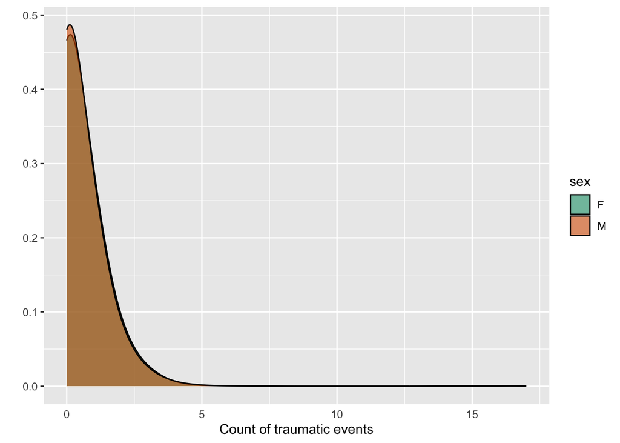

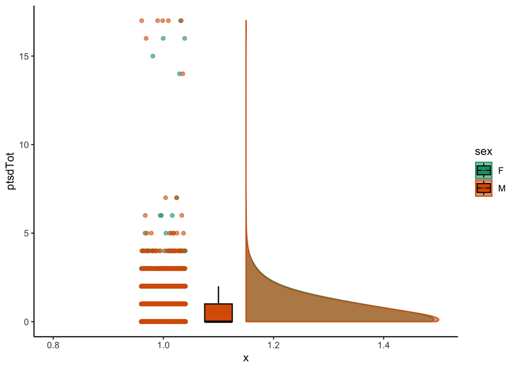

[output not shown]

Get female trauma dataframe only

N = 5680 (complete cases = 5528)

```
## [1] 5528
```

### BPM

Youth internalising difficulties will be assessed using the youth-report Brief Problem Monitor (BPM; Achenbach, 2009), which examines youth behaviour and symptoms over the past week. We will use the BPM data from T4 when youth are aged 12-13 years. The youth-report BPM comprises 19 items rated as 0 (“not true”), 1 (“somewhat true”), and 2 (“very true”), which can be grouped into three domains (attention, internalising, and externalising).

- Use variable: bpm_y_scr_internal_r
- Data dictionary expl: This is the raw score of bpm_9_y plus bpm_11_y plus bpm_12_y plus bpm_13_y plus bpm_18_y plus bpm_19_y Validation: All items must be answered

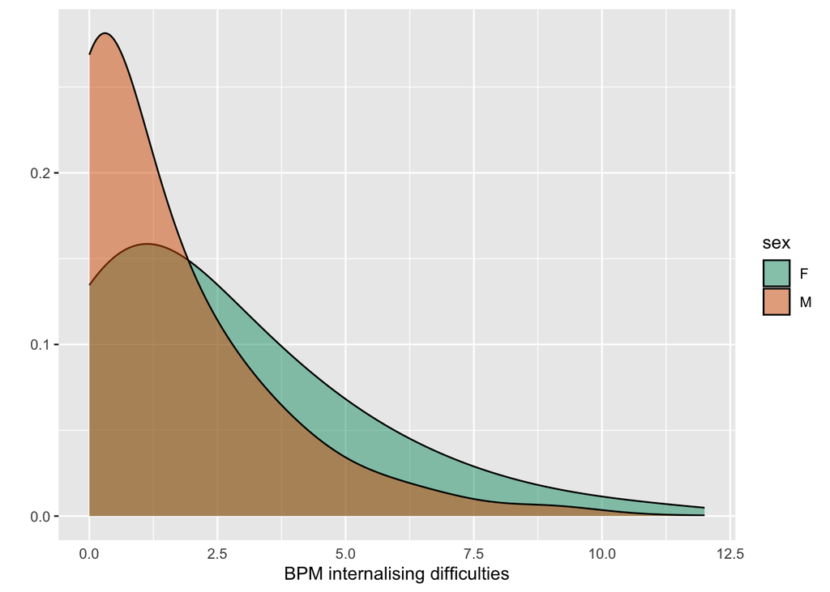

```
##  src_subject_id     interview_age   interview_date         sex
##  Length:6251        Min.   :137.0   Length:6251        Length:6251
##  Class :character   1st Qu.:148.0   Class :character   Class :character
##  Mode  :character   Median :155.0   Mode  :character   Mode  :character
##                     Mean   :154.7
##                     3rd Qu.:161.0
##                     Max.   :174.0
##
##   eventname         bpm_y_scr_internal_r
##  Length:6251        Min.   : 0.000
##  Class :character   1st Qu.: 0.000
##  Mode  :character   Median : 1.000
##                     Mean   : 1.965
##                     3rd Qu.: 3.000
##                     Max.   :12.000
##                     NA's   :163
```

```
##  src_subject_id     interview_age   interview_date         sex
##  Length:2955        Min.   :137.0   Length:2955        Length:2955
##  Class :character   1st Qu.:148.0   Class :character   Class :character
##  Mode  :character   Median :155.0   Mode  :character   Mode  :character
##                     Mean   :154.6
##                     3rd Qu.:161.0
##                     Max.   :171.0
##
##   eventname         bpm_y_scr_internal_r
##  Length:2955        Min.   : 0.000
##  Class :character   1st Qu.: 0.000
##  Mode  :character   Median : 2.000
##                     Mean   : 2.522
##                     3rd Qu.: 4.000
##                     Max.   :12.000
##                     NA's   :83
```

###Covariates

Age (fixed effect) Site (random effect) Family (random effect)

We will undertake sensitivity analyses to examine whether other factors such as family income (income to needs ratio), parental education, race, and BMI, influence the effects observed in our main models.

```
##     src_subject_id interview_date interview_age sex                eventname
## 1 NDAR_INV02WP3TP6     12/09/2017           114   M    baseline_year_1_arm_1
## 2 NDAR_INV030W95VP     09/25/2018           147   F 18_month_follow_up_arm_1
## 3 NDAR_INV030X9ZNH     12/17/2020           157   F 2_year_follow_up_y_arm_1
## 4 NDAR_INV0314RN9P     05/21/2018           110   M    baseline_year_1_arm_1
## 5 NDAR_INV03BDCNWM     06/25/2019           141   F 2_year_follow_up_y_arm_1
## 6 NDAR_INV03BDCNWM     04/22/2017           115   F    baseline_year_1_arm_1
##   site_id_l sched_delay sched_hybrid
## 1    site13           7           NA
## 2    site19          NA           NA
## 3    site11           9            1
## 4    site17           7           NA
## 5    site13           7           NA
## 6    site13           7           NA
```

```
##     src_subject_id interview_date interview_age sex                eventname
## 1 NDAR_INV0YLE20YZ     02/09/2019           127   F 1_year_follow_up_y_arm_1
## 2 NDAR_INV0YLLNXRL     10/20/2017           109   M    baseline_year_1_arm_1
## 3 NDAR_INV0Z5FF0JL     09/05/2018           132   F 1_year_follow_up_y_arm_1
## 4 NDAR_INV0Z5FF0JL     09/20/2017           121   F    baseline_year_1_arm_1
## 5 NDAR_INV101HGWPC     12/19/2017           121   M    baseline_year_1_arm_1
## 6 NDAR_INV10FDVE0L     01/03/2019           129   F 1_year_follow_up_y_arm_1
##   race_ethnicity rel_family_id rel_group_id rel_ingroup_order rel_relationship
## 1          Other            NA           NA                NA             twin
## 2          Black           860            1                 1          sibling
## 3       Hispanic            NA           NA                NA             <NA>
## 4          White          6688            1                 1          triplet
## 5          Asian          4015            2                 1          sibling
## 6          White            NA           NA                NA             <NA>
##   rel_same_sex acs_raked_propensity_score genetic_paired_subjectid_4
```

[output cut: 41 more lines]

## Merge Cleaned Data

Let’s create a clean data frame of youth that have completed the year 3 follow-up. This will allow us to estimate how much missing data we actually have in our final sample.

First get list of “valid IDs”, i.e., those in the femaleIntDiff dataframe.

```
## [1] 2955
```

```
##  [1] "src_subject_id"               "interview_age.x"
##  [3] "interview_date.x"             "sex.x"
##  [5] "eventname.x"                  "bpm_y_scr_internal_r"
##  [7] "interview_date.y"             "interview_age.y"
##  [9] "sex.y"                        "eventname.y"
## [11] "accident_car"                 "accident_other"
## [13] "fire"                         "nat_disaster"
## [15] "witness_terorism"             "witness_war_zone"
## [17] "witness_stab_shoot"           "shot_stab_non_fam"
## [19] "shot_stab_by_adult_home"      "beaten_bruises_by_adult_home"
## [21] "threat_kill_non_fam"          "threat_kill_fam"
## [23] "witness_grown_up_fight"       "sex_abuse_by_adult_home"
## [25] "sex_abuse_non_fam"            "sex_abuse_by_peer"
## [27] "sudden_death_loved_one"       "ptsdTot"
## [29] "interview_date"               "interview_age"
## [31] "sex.x.x"                      "eventname.x.x"
## [33] "pds_1_p"                      "pds_2_p"
## [35] "pds_3_p"                      "pds_f4_p"
## [37] "pds_f5b_p"                    "time"
## [39] "pds_avg"                      "pds_tot"
## [41] "eventname.y.y"                "sex.y.y"
## [43] "rel_family_id"                "rel_group_id"
## [45] "site_id_l"
```

```
##  src_subject_id        sex.x           bpm_y_scr_internal_r accident_car
##  Length:11720       Length:11720       Min.   : 0.000       No  :10886
##  Class :character   Class :character   1st Qu.: 0.000       Yes :  452
##  Mode  :character   Mode  :character   Median : 2.000       NA's:  382
##                                        Mean   : 2.523
##                                        3rd Qu.: 4.000
##                                        Max.   :12.000
##                                        NA's   :325
##  accident_other   fire       nat_disaster witness_terorism witness_war_zone
##  No  :10843     No  :11131   No  :11080   No  :11295       No  :11302
##  Yes :  495     Yes :  207   Yes :  258   Yes :   43       Yes :   36
##  NA's:  382     NA's:  382   NA's:  382   NA's:  382       NA's:  382
##
##
##
##
##  witness_stab_shoot shot_stab_non_fam shot_stab_by_adult_home
##  No  :11278         No  :11318        No  :11314
##  Yes :   60         Yes :   20        Yes :   24
##  NA's:  382         NA's:  382        NA's:  382
##
##
##
##
##  beaten_bruises_by_adult_home threat_kill_non_fam threat_kill_fam
##  No  :11258                   No  :11278          No  :11276
##  Yes :   80                   Yes :   60          Yes :   62
##  NA's:  382                   NA's:  382          NA's:  382
##
##
##
##
##  witness_grown_up_fight sex_abuse_by_adult_home sex_abuse_non_fam
##  No  :10527             No  :11270              No  :11242
##  Yes :  811             Yes :   68              Yes :   96
##  NA's:  382             NA's:  382              NA's:  382
##
##
##
##
```

[output cut: 17 more lines]

```
##  Min.   :1.00   Length:11720       Min.   :1.000   Min.   : 5.00
##  1st Qu.:1.00   Class :character   1st Qu.:1.600   1st Qu.: 8.00
##  Median :1.00   Mode  :character   Median :2.200   Median :11.00
##  Mean   :1.89                      Mean   :2.295   Mean   :11.48
##  3rd Qu.:4.00                      3rd Qu.:3.000   3rd Qu.:15.00
##  Max.   :4.00                      Max.   :4.000   Max.   :20.00
##  NA's   :233                       NA's   :832     NA's   :832
##  rel_family_id    rel_group_id    site_id_l
##  Min.   :    3   Min.   :1.000   Length:11720
##  1st Qu.: 3159   1st Qu.:1.000   Class :character
##  Median : 6008   Median :1.000   Mode  :character
##  Mean   : 6079   Mean   :1.089
##  3rd Qu.: 9000   3rd Qu.:1.000
##  Max.   :11880   Max.   :3.000
##
```

```
##  [1] "src_subject_id"               "sex.x"
##  [3] "bpm_y_scr_internal_r"         "accident_car"
##  [5] "accident_other"               "fire"
##  [7] "nat_disaster"                 "witness_terorism"
##  [9] "witness_war_zone"             "witness_stab_shoot"
## [11] "shot_stab_non_fam"            "shot_stab_by_adult_home"
## [13] "beaten_bruises_by_adult_home" "threat_kill_non_fam"
## [15] "threat_kill_fam"              "witness_grown_up_fight"
## [17] "sex_abuse_by_adult_home"      "sex_abuse_non_fam"
## [19] "sex_abuse_by_peer"            "sudden_death_loved_one"
## [21] "ptsdTot"                      "interview_date"
## [23] "interview_age"                "pds_1_p"
## [25] "pds_2_p"                      "pds_3_p"
## [27] "pds_f4_p"                     "pds_f5b_p"
## [29] "time"                         "pds_avg"
## [31] "pds_tot"                      "rel_family_id"
## [33] "rel_group_id"                 "site_id_l"
```

```
##  [1] "src_subject_id"               "sex"
##  [3] "BPM_T4"                       "accident_car"
##  [5] "accident_other"               "fire"
##  [7] "nat_disaster"                 "witness_terorism"
##  [9] "witness_war_zone"             "witness_stab_shoot"
## [11] "shot_stab_non_fam"            "shot_stab_by_adult_home"
## [13] "beaten_bruises_by_adult_home" "threat_kill_non_fam"
## [15] "threat_kill_fam"              "witness_grown_up_fight"
## [17] "sex_abuse_by_adult_home"      "sex_abuse_non_fam"
## [19] "sex_abuse_by_peer"            "sudden_death_loved_one"
## [21] "trauma_T1"                    "interview_date"
## [23] "interview_age"                "pds_1_p"
## [25] "pds_2_p"                      "pds_3_p"
## [27] "pds_f4_p"                     "pds_f5b_p"
## [29] "time"                         "pds_avg"
## [31] "pds_tot"                      "rel_family_id"
## [33] "rel_group_id"                 "site_id_l"
```

##Prepare clean data frame

Our merged dataframe is currently in long format, where we have one row for each participant per timepoint. We need to convert this to wide format so that we have a separate variable for each of timepoint.

We need to: - Convert age from months to years - Get separate age, pds_avg and pds_tot measures for each timepoint (e.g., ageT0, ageT1, ageT2, ageT3 etc.) - Generate pubertal timing measure which is specific to each timepoint

###Reduce dataframe

call dataframe: shortDf

```
##  [1] "src_subject_id"               "sex"
##  [3] "BPM_T4"                       "accident_car"
##  [5] "accident_other"               "fire"
##  [7] "nat_disaster"                 "witness_terorism"
##  [9] "witness_war_zone"             "witness_stab_shoot"
## [11] "shot_stab_non_fam"            "shot_stab_by_adult_home"
## [13] "beaten_bruises_by_adult_home" "threat_kill_non_fam"
## [15] "threat_kill_fam"              "witness_grown_up_fight"
## [17] "sex_abuse_by_adult_home"      "sex_abuse_non_fam"
## [19] "sex_abuse_by_peer"            "sudden_death_loved_one"
## [21] "trauma_T1"                    "interview_date"
## [23] "interview_age"                "pds_1_p"
## [25] "pds_2_p"                      "pds_3_p"
## [27] "pds_f4_p"                     "pds_f5b_p"
## [29] "time"                         "pds_avg"
## [31] "pds_tot"                      "rel_family_id"
## [33] "rel_group_id"                 "site_id_l"
## [35] "age_years"
```

```
##     src_subject_id BPM_T4 trauma_T1 sex time pds_avg pds_tot age_years
## 1 NDAR_INV019DXLU4      1         2   F   T2     3.2      16  12.00000
## 2 NDAR_INV019DXLU4      1         2   F   T1     3.2      16  11.00000
## 3 NDAR_INV019DXLU4      1         2   F   T4     3.2      16  14.16667
## 4 NDAR_INV019DXLU4      1         2   F   T3     3.2      16  13.16667
## 5 NDAR_INV01EN91PG      4         0   F   T4     1.8       9  12.25000
## 6 NDAR_INV01EN91PG      4         0   F   T2     1.2       6  10.41667
##   rel_family_id site_id_l
## 1          7061    site19
## 2          7061    site19
## 3          7061    site19
## 4          7061    site19
## 5          7059    site19
## 6          7059    site19
```

For our exploratory analysis, we also need to generate a pubertal timing score. To do this, we will regress total PDS score on age and use the residual obtained as the measure of timing. We need to do this separately for each timepoint.

###Pubertal timing

```
##   age_years pds_tot pt
## 1        14      52  3
## 2        16      48 -1
## 3        NA      50 NA
## 4        13      NA NA
## 5        15      45 NA
## 6        17      51 NA
```

```
##        src_subject_id BPM_T4 trauma_T1 sex time pds_avg pds_tot age_years
## 1    NDAR_INV019DXLU4      1         2   F   T2     3.2      16 12.000000
## 2    NDAR_INV019DXLU4      1         2   F   T1     3.2      16 11.000000
## 3    NDAR_INV019DXLU4      1         2   F   T4     3.2      16 14.166667
## 4    NDAR_INV019DXLU4      1         2   F   T3     3.2      16 13.166667
## 5    NDAR_INV01EN91PG      4         0   F   T4     1.8       9 12.250000
## 6    NDAR_INV01EN91PG      4         0   F   T2     1.2       6 10.416667
## 7    NDAR_INV01EN91PG      4         0   F   T1     1.4       7  9.416667
## 8    NDAR_INV01EN91PG      4         0   F   T3     2.2      11 11.416667
## 9    NDAR_INV02UVMTY7      2         0   F   T3     3.4      17 12.916667
## 10   NDAR_INV02UVMTY7      2         0   F   T4     4.0      20 13.833333
## 11   NDAR_INV02UVMTY7      2         0   F   T2     2.6      13 11.833333
## 12   NDAR_INV02UVMTY7      2         0   F   T1     2.2      11 10.833333
## 13   NDAR_INV03XVEBPM      0        NA   F   T2     1.4       7 11.000000
## 14   NDAR_INV03XVEBPM      0        NA   F   T3     1.6       8 12.166667
```

[output cut: 18168 more lines]

##Export cleaned data

###Convert from long to wide

Residuals are slightly different when generated using long and wide format data – need to double check this with co-authors (30.05.23)

Some notes: - We only have BPM from T4

```
##  [1] "src_subject_id" "sex"            "age_years_T1"   "age_years_T2"
##  [5] "age_years_T3"   "age_years_T4"   "site_id_l"      "rel_family_id"
##  [9] "trauma_T1"      "BPM_T4"         "pds_avg_T1"     "pds_avg_T2"
## [13] "pds_avg_T3"     "pds_avg_T4"     "pds_tot_T1"     "pds_tot_T2"
## [17] "pds_tot_T3"     "pds_tot_T4"
```

## Archived code

This is code for variable data cleaning that wasn’t used in the current analysis but might be useful at a later stage.

### Youth PDS cleaning and scoring

```
##
##     1     2     3     4   777   999
##  6194 10391 14450  2621   415  5580
```

```
##
##     1     2     3     4   777   999
## 13574 13450  9202  1103   322  2000
```

```
##
##     1     2     3     4   777   999
## 13566 12084 10253  2273   615   859
```

```
##
##    1    2    3    4  777  999
## 3347 6722 6411  661  553 1131
```

```
##
##     1     4   777   999
## 13059  4518   574   680
```

Get average PDS score

Note: need to think about how to handle missing data for predictor

Density plot of PDS per timepoint

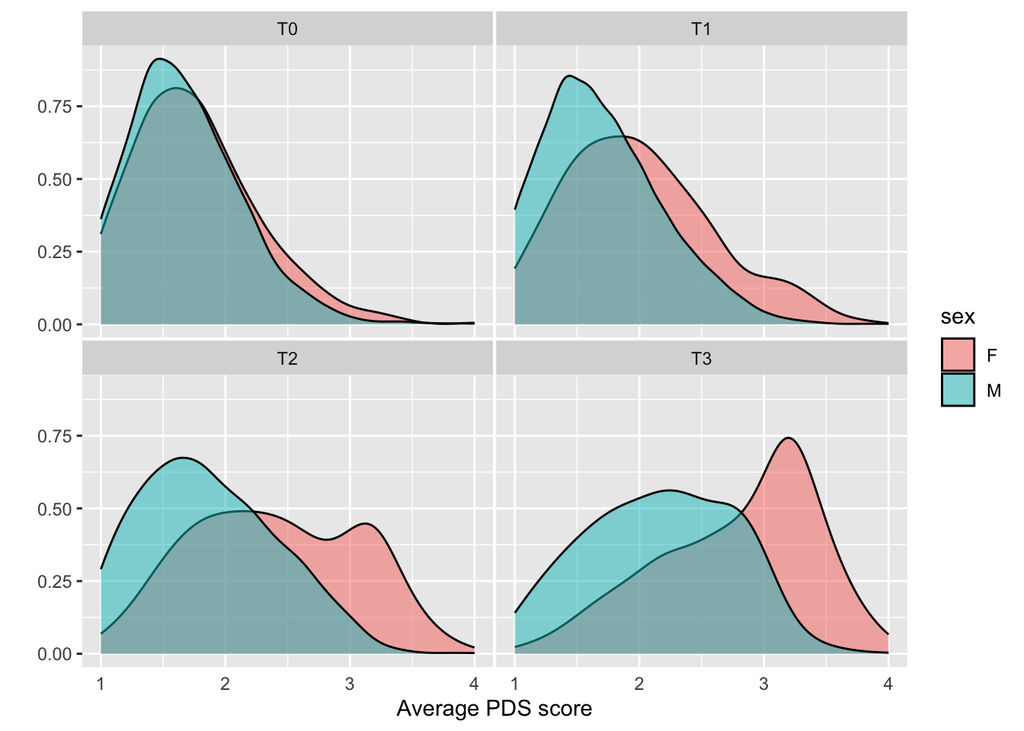

Raincloud plots - playing around with ggrain.

See vignette: https://www.njudd.com/raincloud-ggrain/

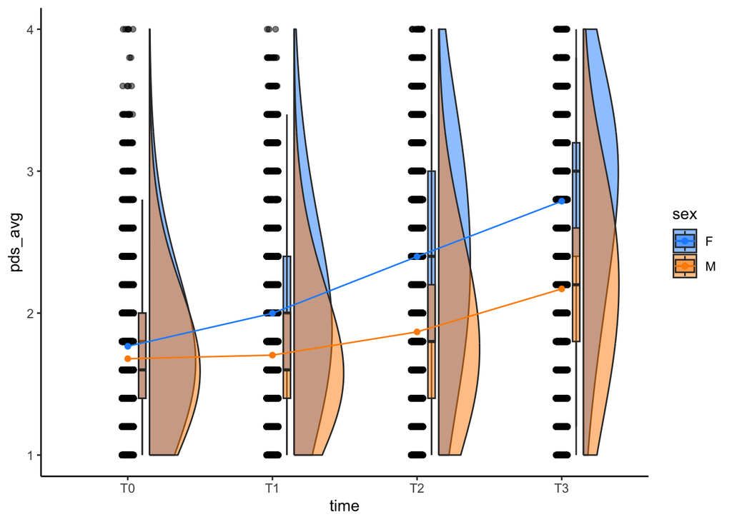

We are going to use female adolescents only in our main analyses so let’s explore the PDS data for females only further

| **Characteristic** | **T0**, N = 5,680<sup>1</sup> | **T1**, N = 5,353<sup>1</sup> | **T2**, N = 4,962<sup>1</sup> | **T3**, N = 2,955<sup>1</sup> | **p-value**<sup>2</sup> |
| --- | --- | --- | --- | --- | --- |
| age | 118.81 (7.48) | 130.90 (7.72) | 143.91 (7.99) | 154.56 (7.63) | <0.001 |
| Height change |  |  |  |  | <0.001 |
| 1 | 595 / 3,282 | 848 / 4,628 | 691 / 4,875 | 256 / 2,916 |  |
| 2 | 1,053 / 3,282 | 1,471 / 4,628 | 1,394 / 4,875 | 612 / 2,916 |  |
| 3 | 1,267 / 3,282 | 2,000 / 4,628 | 2,298 / 4,875 | 1,519 / 2,916 |  |
| 4 | 367 / 3,282 | 309 / 4,628 | 492 / 4,875 | 529 / 2,916 |  |
| Missing (N) | 2,398 | 725 | 87 | 39 |  |
| Skin changes |  |  |  |  | <0.001 |
| 1 | 2,488 / 4,925 | 1,700 / 5,127 | 820 / 4,905 | 254 / 2,924 |  |
| 2 | 1,771 / 4,925 | 2,108 / 5,127 | 1,905 / 4,905 | 861 / 2,924 |  |
| 3 | 533 / 4,925 | 1,167 / 5,127 | 2,018 / 4,905 | 1,642 / 2,924 |  |
| 4 | 133 / 4,925 | 152 / 5,127 | 162 / 4,905 | 167 / 2,924 |  |
| Missing (N) | 755 | 226 | 57 | 31 |  |
| Body hair changes |  |  |  |  | <0.001 |
| 1 | 2,584 / 5,302 | 1,730 / 5,073 | 741 / 4,797 | 177 / 2,877 |  |
| 2 | 1,704 / 5,302 | 1,702 / 5,073 | 1,414 / 4,797 | 580 / 2,877 |  |
| 3 | 698 / 5,302 | 1,416 / 5,073 | 2,191 / 4,797 | 1,558 / 2,877 |  |
| 4 | 316 / 5,302 | 225 / 5,073 | 451 / 4,797 | 562 / 2,877 |  |
| Missing (N) | 378 | 280 | 165 | 78 |  |
| Breast development |  |  |  |  | <0.001 |
| 1 | 1,738 / 4,602 | 1,074 / 4,951 | 426 / 4,732 | 109 / 2,855 |  |
| 2 | 1,980 / 4,602 | 2,162 / 4,951 | 1,771 / 4,732 | 809 / 2,855 |  |
| 3 | 758 / 4,602 | 1,599 / 4,951 | 2,350 / 4,732 | 1,703 / 2,855 |  |
| 4 | 126 / 4,602 | 116 / 4,951 | 185 / 4,732 | 234 / 2,855 |  |
| Missing (N) | 1,078 | 402 | 230 | 100 |  |
| Began menstruation |  |  |  |  | <0.001 |
| 1 | 4,873 / 5,038 | 4,339 / 5,007 | 2,859 / 4,707 | 987 / 2,824 |  |
| 4 | 165 / 5,038 | 668 / 5,007 | 1,848 / 4,707 | 1,837 / 2,824 |  |
| Missing (N) | 642 | 346 | 255 | 131 |  |
| PDS average score | 1.77 (0.50) | 2.00 (0.59) | 2.40 (0.67) | 2.79 (0.63) | <0.001 |
| Missing (N) | 3,236 | 1,209 | 461 | 210 |  |

<sup>1</sup> Mean (SD); n / N  
<sup>2</sup> Kruskal-Wallis rank sum test; Pearson’s Chi-squared test